# Cleaning and Analysing Data with RBQL

## By Joe Palmer

In this notebook we will take a small dataset of dice rolls and tidy it up so that it is consistent and easy to work with. Real world data is often messy. The same value can be written in many different ways, and some values can be missing altogether. Before we can analyse data we usually need to clean it first.

We will use a tool called RBQL (Rainbow Query Language). RBQL lets us write SQL style queries that use ordinary Python expressions, which makes it a good way to learn the ideas behind data cleaning. Once the data is clean we will produce a couple of bar charts to summarise it. Work through the cells in order from top to bottom and read the explanation above each one before you run it.

## Step 1: Set up the tools

The cell below installs the libraries we need and then loads them. The `pandas` library gives us the DataFrame, which is a table of rows and columns much like a spreadsheet. The `matplotlib` library lets us draw charts, and we import its plotting part under the short name `plt`. The `rbql` library lets us run RBQL queries inside the notebook.

The `%load_ext rbql` line switches on the `%rbql` magic command, which we will use further down. You only need to run this cell once at the start of your session. If you restart the kernel you will need to run it again.

```python
%pip --quiet install pandas
%pip --quiet install matplotlib
%pip --quiet install rbql

import pandas as pd
import matplotlib.pyplot as plt
%load_ext rbql
```

```
The rbql extension is already loaded. To reload it, use:
  %reload_ext rbql
```

## Step 2: Load the data

Here we read our data from a file called `rolls.csv` into a DataFrame named `df`. A CSV file is just a plain text file where the values are separated by commas. The first row holds the column headings, which in our case are `name`, `hand`, and `roll`.

Notice the `keep_default_na=False` setting. By default pandas tries to be helpful and turns empty cells into a special "not a number" value. We have turned that behaviour off so that empty cells stay as empty text, which makes them easier to spot and fix later.

When you run the cell the table is displayed underneath. Take a moment to look at the problems in the data. The names are written with different capitalisation, the hand column mixes single letters with full words, and some names are missing entirely.

```python
df = pd.read_csv("rolls.csv", keep_default_na=False)

df
```

|  | name | hand | roll |
| --- | --- | --- | --- |
| 0 | alice | L | 4 |
| 1 | Alice | Right | 6 |
| 2 | ALICE | Right | 4 |
| 3 | Alice | Left | 1 |
| 4 | alice | Right | 3 |
| 5 | Bob | R | 1 |
| 6 | BOB | Right | 2 |
| 7 | bob | L | 6 |
| 8 | Bob | R | 6 |
| 9 | bob | Left | 1 |
| 10 | Carlos | L | 6 |
| 11 | carlos | Left | 4 |
| 12 | CARLOS | Right | 6 |
| 13 | carlos | L | 3 |
| 14 | Carlos | L | 6 |
| 15 |  | Left | 5 |
| 16 |  | Left | 6 |
| 17 |  | Left | 5 |
| 18 |  | L | 2 |
| 19 |  | Left | 5 |

## Step 3: Fill in the missing names

The first problem we will fix is the missing names. Several rows have an empty `name` field, which is not very useful when we come to analyse the data.

The query below uses `UPDATE` to change values in place. The `WHERE` part acts as a filter, so the change only happens on the rows where the condition is true. Here the condition `a.name == ""` is true only for rows where the name is an empty string. For those rows we set the name to the word `Unknown`. Every other row is left exactly as it was.

In RBQL the letter `a` refers to the current table, so `a.name` means the value in the `name` column for the row being processed.

```python
clean_df = %rbql UPDATE SET a.name = 'Unknown' WHERE a.name == "" FROM df

clean_df
```

|  | name | hand | roll |
| --- | --- | --- | --- |
| 0 | alice | L | 4 |
| 1 | Alice | Right | 6 |
| 2 | ALICE | Right | 4 |
| 3 | Alice | Left | 1 |
| 4 | alice | Right | 3 |
| 5 | Bob | R | 1 |
| 6 | BOB | Right | 2 |
| 7 | bob | L | 6 |
| 8 | Bob | R | 6 |
| 9 | bob | Left | 1 |
| 10 | Carlos | L | 6 |
| 11 | carlos | Left | 4 |
| 12 | CARLOS | Right | 6 |
| 13 | carlos | L | 3 |
| 14 | Carlos | L | 6 |
| 15 | Unknown | Left | 5 |
| 16 | Unknown | Left | 6 |
| 17 | Unknown | Left | 5 |
| 18 | Unknown | L | 2 |
| 19 | Unknown | Left | 5 |

## Step 4: Make the capitalisation consistent

Look at the names again. We have `alice`, `Alice`, and `ALICE`, but these all refer to the same person. A computer treats each of these as a completely different value because the letters are in a different case. To fix this we make every name follow the same pattern.

The `title()` method is a built in Python function that puts the first letter of each word in capitals and makes the rest lower case. So `alice` becomes `Alice` and `ALICE` also becomes `Alice`. Because we are not using a `WHERE` filter this time, the change is applied to every row in the table.

```python
clean_df = %rbql UPDATE SET a.name = a.name.title() FROM clean_df

clean_df
```

|  | name | hand | roll |
| --- | --- | --- | --- |
| 0 | Alice | L | 4 |
| 1 | Alice | Right | 6 |
| 2 | Alice | Right | 4 |
| 3 | Alice | Left | 1 |
| 4 | Alice | Right | 3 |
| 5 | Bob | R | 1 |
| 6 | Bob | Right | 2 |
| 7 | Bob | L | 6 |
| 8 | Bob | R | 6 |
| 9 | Bob | Left | 1 |
| 10 | Carlos | L | 6 |
| 11 | Carlos | Left | 4 |
| 12 | Carlos | Right | 6 |
| 13 | Carlos | L | 3 |
| 14 | Carlos | L | 6 |
| 15 | Unknown | Left | 5 |
| 16 | Unknown | Left | 6 |
| 17 | Unknown | Left | 5 |
| 18 | Unknown | L | 2 |
| 19 | Unknown | Left | 5 |

## Step 5: Start tidying the hand column

Now we turn to the `hand` column. It currently contains a mixture of values such as `L`, `Left`, `R`, and `Right`, written with different capitalisation. Our goal is to end up with just `L` for left and `R` for right.

We will do this in three smaller steps because breaking a problem down into simpler parts is good practice. This first step uses `upper()` to convert every value to capital letters. After running it the column will only contain `L`, `LEFT`, `R`, or `RIGHT`. This removes the casing differences so that the next steps have fewer cases to deal with.

```python
clean_df = %rbql UPDATE SET a.hand = a.hand.upper() FROM clean_df

clean_df
```

|  | name | hand | roll |
| --- | --- | --- | --- |
| 0 | Alice | L | 4 |
| 1 | Alice | RIGHT | 6 |
| 2 | Alice | RIGHT | 4 |
| 3 | Alice | LEFT | 1 |
| 4 | Alice | RIGHT | 3 |
| 5 | Bob | R | 1 |
| 6 | Bob | RIGHT | 2 |
| 7 | Bob | L | 6 |
| 8 | Bob | R | 6 |
| 9 | Bob | LEFT | 1 |
| 10 | Carlos | L | 6 |
| 11 | Carlos | LEFT | 4 |
| 12 | Carlos | RIGHT | 6 |
| 13 | Carlos | L | 3 |
| 14 | Carlos | L | 6 |
| 15 | Unknown | LEFT | 5 |
| 16 | Unknown | LEFT | 6 |
| 17 | Unknown | LEFT | 5 |
| 18 | Unknown | L | 2 |
| 19 | Unknown | LEFT | 5 |

## Step 6: Convert the full word LEFT to L

Now that the casing is consistent we can replace the long form with the short form. This query filters for rows where the hand value is exactly `LEFT` and sets those values to `L`.

Rows that already contain `L` are not matched by the `WHERE` condition, so they are left alone. After this step the only values representing left will be `L`.

```python
clean_df = %rbql UPDATE SET a.hand = "L" WHERE a.hand == "LEFT" FROM clean_df

clean_df
```

|  | name | hand | roll |
| --- | --- | --- | --- |
| 0 | Alice | L | 4 |
| 1 | Alice | RIGHT | 6 |
| 2 | Alice | RIGHT | 4 |
| 3 | Alice | L | 1 |
| 4 | Alice | RIGHT | 3 |
| 5 | Bob | R | 1 |
| 6 | Bob | RIGHT | 2 |
| 7 | Bob | L | 6 |
| 8 | Bob | R | 6 |
| 9 | Bob | L | 1 |
| 10 | Carlos | L | 6 |
| 11 | Carlos | L | 4 |
| 12 | Carlos | RIGHT | 6 |
| 13 | Carlos | L | 3 |
| 14 | Carlos | L | 6 |
| 15 | Unknown | L | 5 |
| 16 | Unknown | L | 6 |
| 17 | Unknown | L | 5 |
| 18 | Unknown | L | 2 |
| 19 | Unknown | L | 5 |

## Step 7: Convert the full word RIGHT to R

This is the last cleaning step and it follows the same idea as the previous one. We filter for rows where the hand value is exactly `RIGHT` and set those values to `R`.

Once you run this cell the `hand` column will be fully standardised. Every value will be either `L` or `R`, the names will all use consistent capitalisation, and there will be no missing names. The dataset is now clean and ready to be analysed.

```python
clean_df = %rbql UPDATE SET a.hand = "R" WHERE a.hand == "RIGHT" FROM clean_df

clean_df
```

|  | name | hand | roll |
| --- | --- | --- | --- |
| 0 | Alice | L | 4 |
| 1 | Alice | R | 6 |
| 2 | Alice | R | 4 |
| 3 | Alice | L | 1 |
| 4 | Alice | R | 3 |
| 5 | Bob | R | 1 |
| 6 | Bob | R | 2 |
| 7 | Bob | L | 6 |
| 8 | Bob | R | 6 |
| 9 | Bob | L | 1 |
| 10 | Carlos | L | 6 |
| 11 | Carlos | L | 4 |
| 12 | Carlos | R | 6 |
| 13 | Carlos | L | 3 |
| 14 | Carlos | L | 6 |
| 15 | Unknown | L | 5 |
| 16 | Unknown | L | 6 |
| 17 | Unknown | L | 5 |
| 18 | Unknown | L | 2 |
| 19 | Unknown | L | 5 |

## Step 8: Plot the mean roll for each person

Now that the data is clean we can start to summarise it. This cell uses an RBQL query with `GROUP BY` to gather all the rows for each person together, then works out the average roll for that person using the `AVG` function. We give the result column a clear name with `AS mean_roll`.

The result of the query comes back as a DataFrame, which we store in `mean_roll_by_name`. Note the `int(a.roll)` part. Values read from the file are text to begin with, so we convert each roll into a whole number before we can take an average of it.

We then use `plt.bar()` to draw a bar chart. The first argument gives the labels along the bottom, which are the names, and the second argument gives the height of each bar, which is the mean roll. The `xlabel`, `ylabel`, and `title` lines add labels so the chart is easy to read, and `plt.show()` displays it.

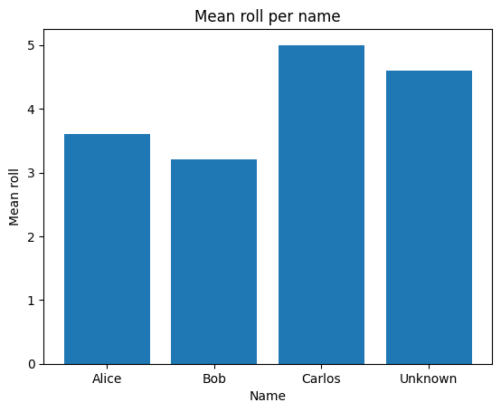

```python
mean_roll_by_name = %rbql SELECT a.name, AVG(int(a.roll)) AS mean_roll GROUP BY a.name FROM clean_df

plt.bar(mean_roll_by_name["name"], mean_roll_by_name["mean_roll"])
plt.xlabel("Name")
plt.ylabel("Mean roll")
plt.title("Mean roll per name")
plt.show()
```

## Step 9: Plot the median roll for each person

This cell is very similar to the previous one, but it shows the median rather than the mean. The mean and the median are two different ways of describing a typical value. The mean is the total of all the rolls divided by how many there are. The median is the middle value once the rolls are placed in order. Comparing the two charts is a good way to see how the choice of average can change the picture.

The query uses the `MEDIAN` function in place of `AVG` and names the result column `median_roll`. Everything else works in the same way as before. The result is stored in `median_roll_by_name` and drawn as a bar chart.

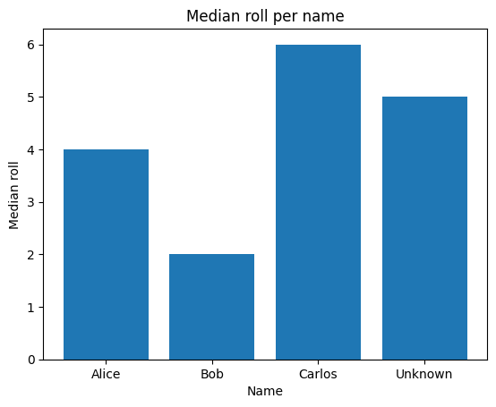

```python
median_roll_by_name = %rbql SELECT a.name, MEDIAN(int(a.roll)) AS median_roll GROUP BY a.name FROM clean_df

plt.bar(median_roll_by_name["name"], median_roll_by_name["median_roll"])
plt.xlabel("Name")
plt.ylabel("Median roll")
plt.title("Median roll per name")
plt.show()
```